# ps1

Jessica Jiang

1/6/2018

```r
library(tidyverse)
```

# 1 R for Data Science Exercises

## 1.1 Intro

1. Who did you work with? Pedro Liedo

## 1.2 3.6.1

##### 1. What geom would you use to draw a line chart? A boxplot? A histogram? An area chart?

**line geom**: geom_line()

**boxplot geom**: geom_boxplot()

**histgram geom**: geom_histogram()

**area chart**: geom_area()

##### 2.What does show.legend = FALSE do? What happens if you remove it? Why do you think I used it earlier in the chapter?

It tells r not to show the legend right next to the chart. Without it, there would be one or multiple legends shown. **You used it because we can have more space for the chart this way.**

##### 3.What does the se argument to geom_smooth() do?

It’s the short of standard error. If se = T, the confidence interval would be displayed around the fitted line.

##### 4. Will these two graphs look different? Why/why not?

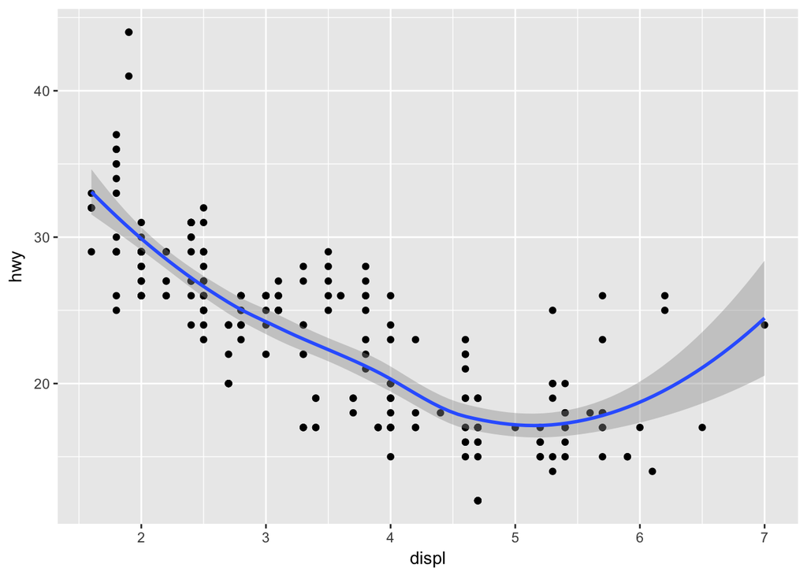

```r
ggplot(data = mpg, mapping = aes(x = displ, y = hwy)) +
geom_point() +
geom_smooth()
```

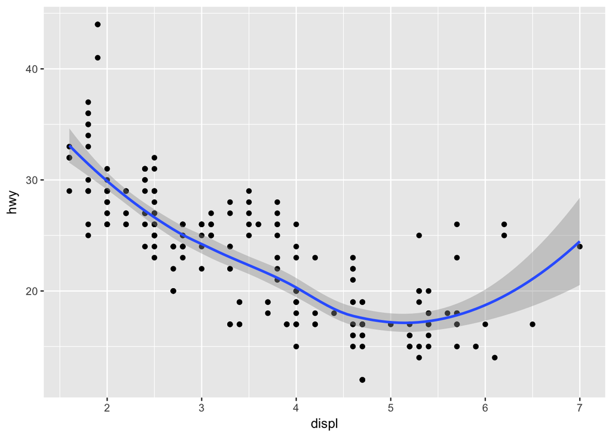

```r
ggplot() +
geom_point(data = mpg, mapping = aes(x = displ, y = hwy)) +
geom_smooth(data = mpg, mapping = aes(x = displ, y = hwy))
```

They will look the same. Because two layers use the same data, coordinate system, by only typing the data and the set of mappings to ggplot(), this mapping is treated as a global mapping that apply to all geoms in the grap. It produces the same plot as the code where we specify the data and mappings in both geoms.

## 1.2.1 3.7.1

1. What is the default geom associated with stat_summary()? How could you rewrite the previous plot to use that geom function instead of the stat function?

default geom: geom_pointrange()

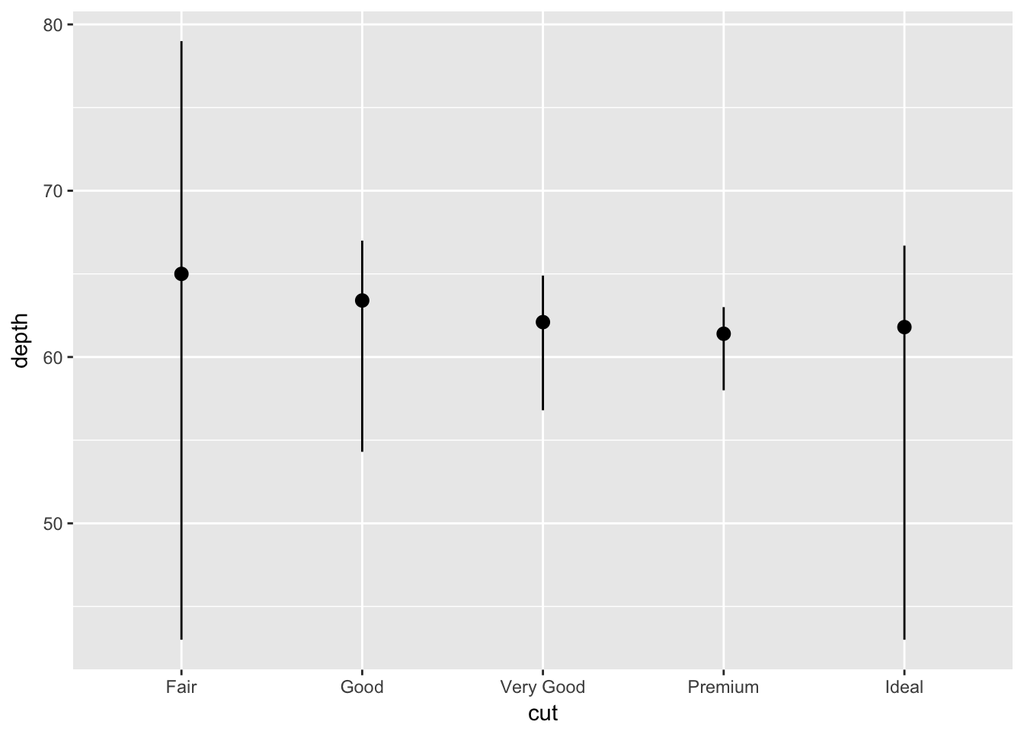

```r
ggplot(data = diamonds,aes(x = cut, y = depth)) +
  geom_pointrange(stat = "summary",
                  fun.ymin = min,
                  fun.ymax = max,
                  fun.y = median
                  )
```

geom_col and geom_b are two types of bar charts: with geom_col, the hight of the bar represent the values of another variable in the data, whereas with geom_bar, the hight of the bar represent the counting of number of cases at each x position.

```r
?geom_col()
?geom_bar()
```

3. Most geoms and stats come in pairs that are almost always used in concert. Read through the documentation and make a list of all the pairs. What do they have in common?

```r
pairs <- c("geom_bar - count", "geom_bin2d - bin2d", "geom_blank - identity", "geom_boxplot - boxplot","geom_contour - contour", "geom_contour - contour", "geom_count - sum", "geom_density - density", "geom_density_2d - density2d","geom_errorbarh - identity", "geom_hex - binhex", "geom_freqpoly - bin", "geom_jitter- identity", "geom_crossbar - identity", "geom_map - identity", "geom_path - identity", "geom_point - identity", "geom_polygon - identity", "geom_qq - stats::qnorm (NA)", "geom_quantile - quantile", "geom_ribbon - identity", "geom_rug - identity", "geom_segment - identity", "geom_smooth - smooth", "geom_spoke -  identity", "geom_label - identity", "geom_raster - identity", "geom_violin - ydensity")

pairs
```

```
##  [1] "geom_bar - count"            "geom_bin2d - bin2d"
##  [3] "geom_blank - identity"       "geom_boxplot - boxplot"
##  [5] "geom_contour - contour"      "geom_contour - contour"
##  [7] "geom_count - sum"            "geom_density - density"
##  [9] "geom_density_2d - density2d" "geom_errorbarh - identity"
## [11] "geom_hex - binhex"           "geom_freqpoly - bin"
## [13] "geom_jitter- identity"       "geom_crossbar - identity"
## [15] "geom_map - identity"         "geom_path - identity"
## [17] "geom_point - identity"       "geom_polygon - identity"
## [19] "geom_qq - stats::qnorm (NA)" "geom_quantile - quantile"
## [21] "geom_ribbon - identity"      "geom_rug - identity"
## [23] "geom_segment - identity"     "geom_smooth - smooth"
## [25] "geom_spoke -  identity"      "geom_label - identity"
## [27] "geom_raster - identity"      "geom_violin - ydensity"
```

4. What variables does stat_smooth() compute? What parameters control its behaviour? -It aids the eye in seeing patterns in the presence of overplotting. -position, method, formula, se, n which is number of points, span, fullrange, level, method.args, na.rm, show.legend and inherit.aes

```r
?stat_smooth()
```

5. In our proportion bar chart, we need to set group = 1. Why? In other words what is the problem with these two graphs?

The right way should be:

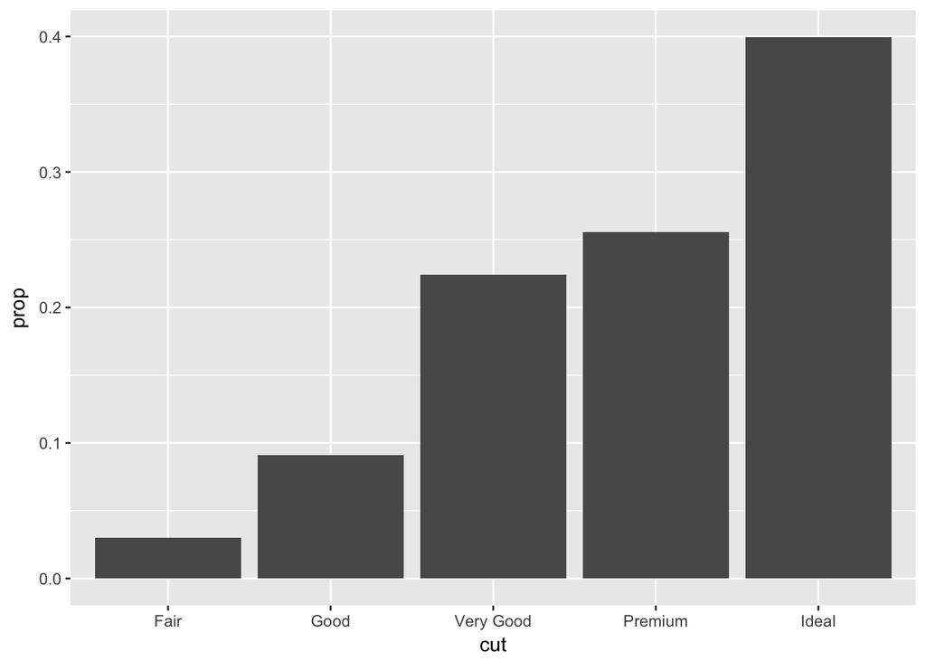

```r
ggplot(data = diamonds) +
geom_bar(mapping = aes(x = cut, y = ..prop.., group = 1))
```

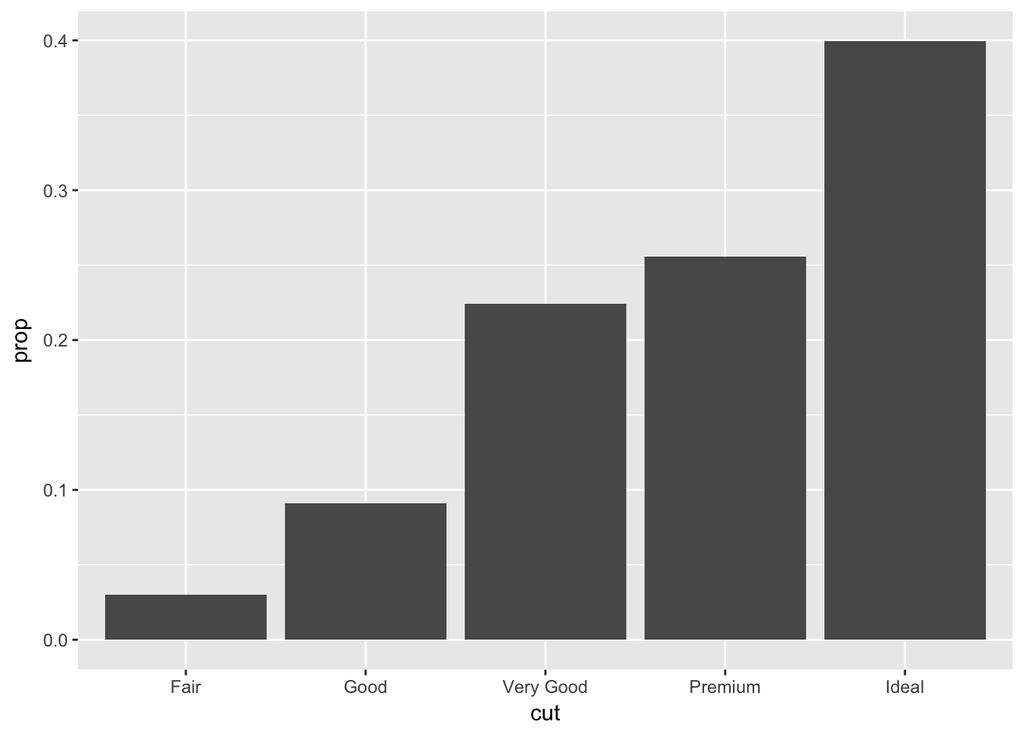

```r
ggplot(data = diamonds) +
geom_bar(mapping = aes(x = cut, fill = color, y = ..prop.., group =1))
```

## 1.3 3.8.1

1. What is the problem with this plot? How could you improve it?

The data has 234 observations; the scatter, however, only shows around 80 observations. This is because some data points overlap with other. By adding geom_jitter(), we add some noise to each data point and this way all observations show in the scatter plot.

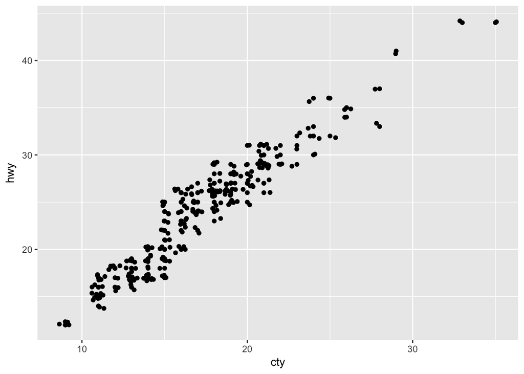

```r
ggplot(data = mpg, mapping = aes(x = cty, y = hwy)) +
  geom_point() +
  geom_jitter()
```

2. What parameters to geom_jitter() control the amount of jittering?

```r
?geom_jitter
```

width and height

3. Compare and contrast geom_jitter() with geom_count().

Both help with overplotting. geom_count counts overlapping points at each location and then maps the count to the point area. geom_jitter adds small amount of noise to the location of each data point.

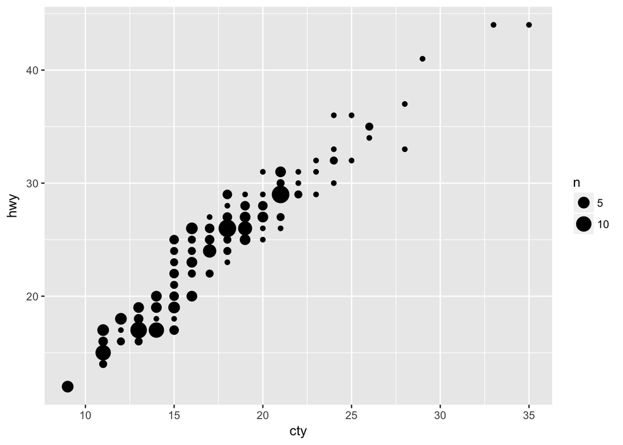

```r
ggplot(data = mpg, mapping = aes(x = cty, y = hwy)) +
  geom_point() +
  geom_count()
```

4. What’s the default position adjustment for geom_boxplot()? Create a visualisation of the mpg dataset that demonstrates it.

the default position adjustment is position = “dodge”. If we add position=‘dodge’ in geom_boxplot(), they look exactly the same.

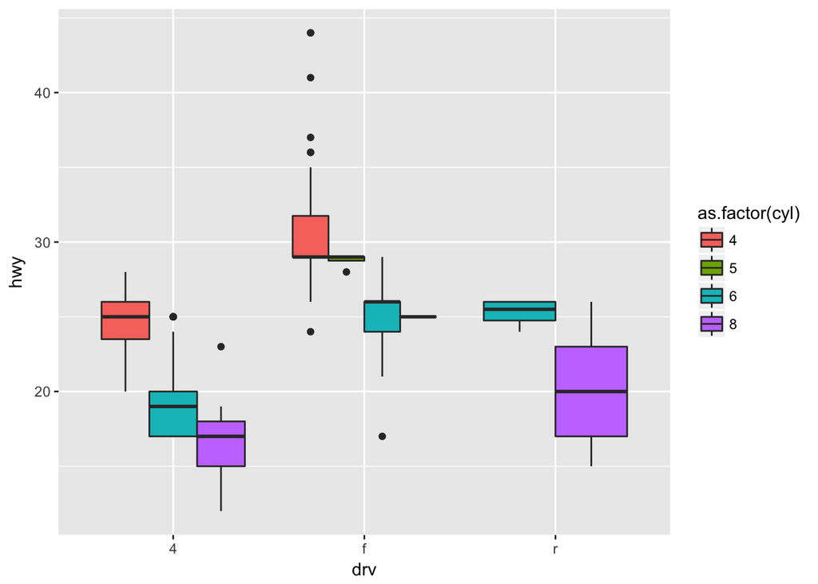

```r
?geom_boxplot

ggplot(mpg, aes(x=drv, y=hwy, fill=as.factor(cyl))) +
  geom_boxplot()
```

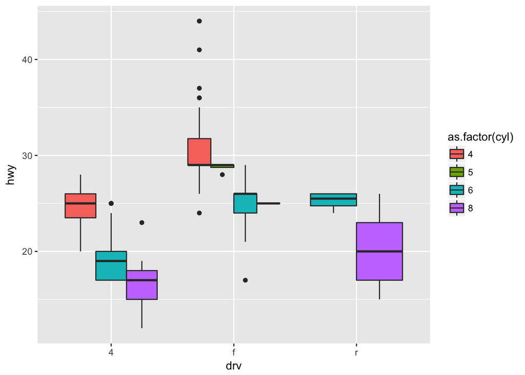

```r
ggplot(mpg, aes(x = drv, y = hwy, fill=as.factor(cyl))) +
  geom_boxplot(position='dodge')
```

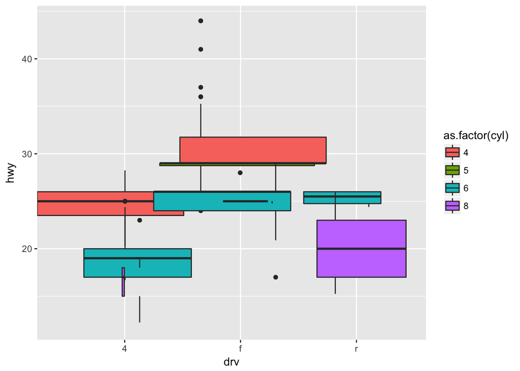

```r
ggplot(mpg, aes(x = drv, y = hwy, fill=as.factor(cyl))) +
  geom_boxplot(position='jitter')
```

## 1.4 3.9.1

1. Turn a stacked bar chart into a pie chart using coord_polar().

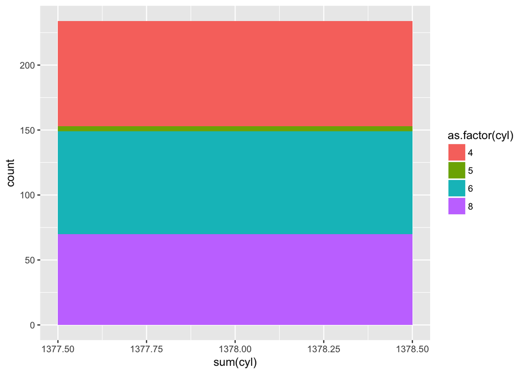

```r
ggplot(mpg, aes(x=sum(cyl), fill=as.factor(cyl))) +
  geom_bar(width = 1)
```

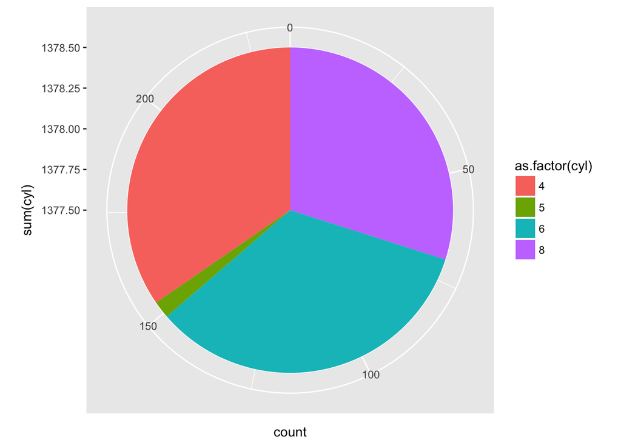

```r
ggplot(mpg, aes(x=sum(cyl), fill=as.factor(cyl))) +
  geom_bar(width = 1) +
  coord_polar(theta = 'y')
```

2. What does labs() do? Read the documentation

```r
?labs()
```

It modifies axis, legend, and plot labels, title and subtitle to the plot.

3. What’s the difference between coord_quickmap() and coord_map()? coord_quickmap uses an approximation to the mercator projection, whereas coord_map can use a variety of projections from the mapproj package.

coord_map uses any projection defined by the mapproj package, whereas coord_quickmap uses a quick approximation to the mercator projection. coord_quickmap is faster and does not require any additional pack but it only works for smaller areas closer to the equater and is less accurate.

```r
?coord_quickmap()
?coord_map()
```

4. What does the plot below tell you about the relationship between city and highway mpg? Why is coord_fixed() important? What does geom_abline() do?

cty and hwy are positively correlated, and there’s approximately a linear relationship between them. However, highway milage is better than city millage. coord_fixed() gives same interval of x- and y- axis and it gives a constant offset and makes it easier for us to compare the relationship between x and y. geom_abline() adds a diagonal reference line to the plot. The default setting of slope is 1 and intercept 0. It adds a line that passes the origin with slope 1.

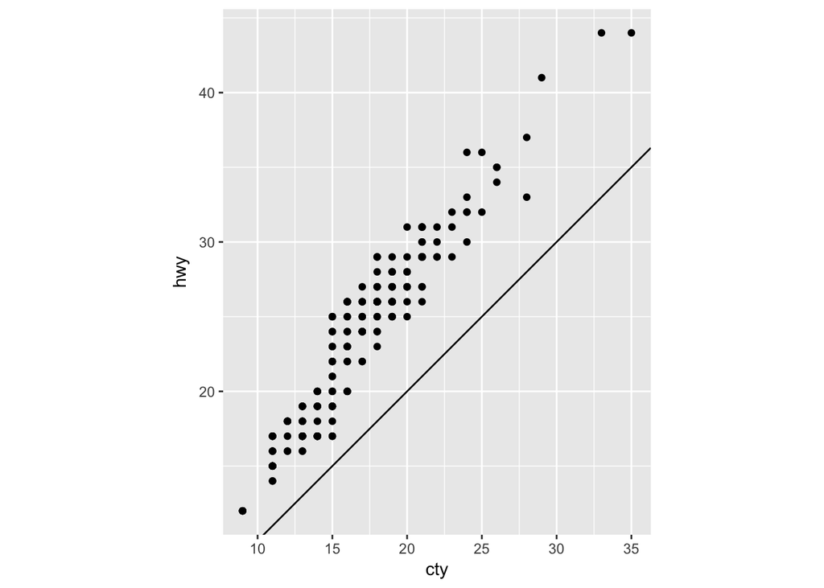

```r
ggplot(data = mpg, mapping = aes(x = cty, y = hwy)) +
geom_point() +
geom_abline() +
coord_fixed()
```

```r
?geom_abline()
```